# Quiz4Week

Ilya Maltsev

19 Apr, 2017

## Question 1

Consider the space shuttle data ?*shuttle* in the *MASS* library. Consider modeling the use of the autolander as the outcome (variable name use). Fit a logistic regression model with autolander (variable auto) use (labeled as “auto” 1) versus not (0) as predicted by wind sign (variable wind). Give the estimated odds ratio for autolander use comparing head winds, labeled as “head” in the variable headwind (numerator) to tail winds (denominator).

- 0.969
- 0.031
- -0.031
- 1.327

```r
library(MASS)
shuttle$useBin = 1 * (shuttle$use == "auto")
shuttle$windBin = 1 * (shuttle$wind == "head")
```

```r
q1fit <- glm(formula = useBin ~ windBin, data = shuttle, family = binomial)
summary(q1fit)
```

```
##
## Call:
## glm(formula = useBin ~ windBin, family = binomial, data = shuttle)
##
## Deviance Residuals:
##    Min      1Q  Median      3Q     Max
## -1.300  -1.286   1.060   1.073   1.073
##
## Coefficients:
##             Estimate Std. Error z value Pr(>|z|)
## (Intercept)  0.28313    0.17855   1.586    0.113
## windBin     -0.03181    0.25224  -0.126    0.900
##
## (Dispersion parameter for binomial family taken to be 1)
##
##     Null deviance: 350.36  on 255  degrees of freedom
## Residual deviance: 350.35  on 254  degrees of freedom
## AIC: 354.35
##
## Number of Fisher Scoring iterations: 4
```

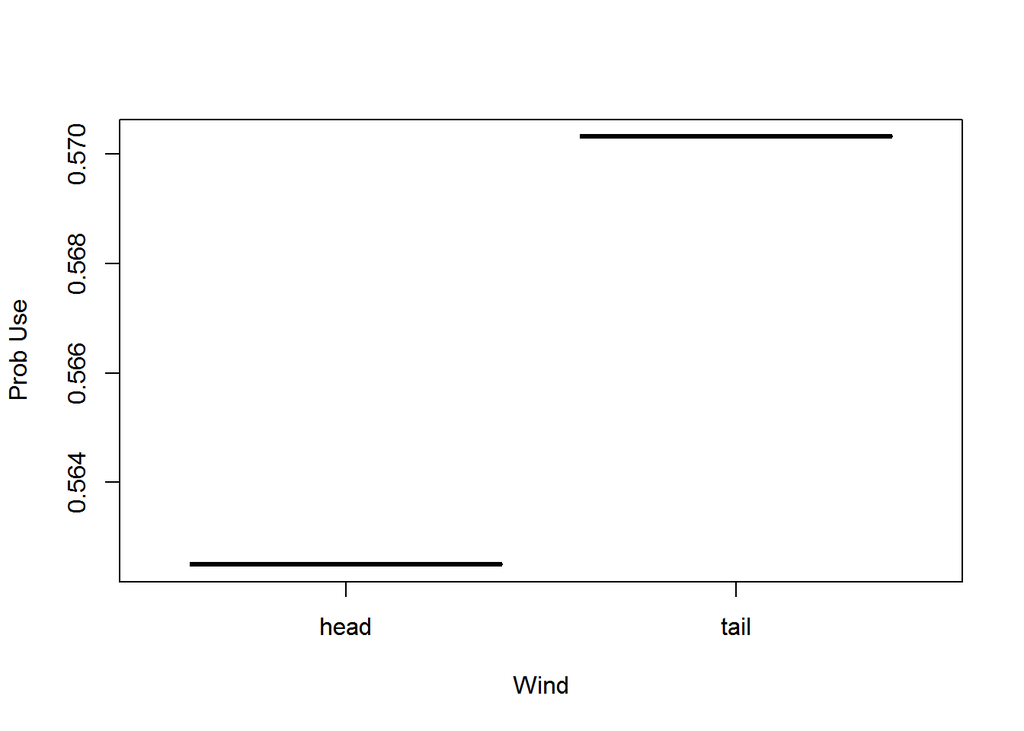

```r
plot(shuttle$wind, q1fit$fitted, pch=19, col="blue",
     xlab="Wind", ylab="Prob Use")
```

Odds ratio is the $\beta_1$ coefficient of the fit:

```r
exp(q1fit$coef[2])
```

```
##   windBin
## 0.9686888
```

## Question 2

Consider the previous problem. Give the estimated odds ratio for autolander use comparing head winds (numerator) to tail winds (denominator) adjusting for wind strength from the variable magn.

- 1.485
- 1.00
- 0.969
- 0.684

```r
library(MASS)
```

```r
shuttle$useBin = 1 * (shuttle$use == "auto")
shuttle$windBin = 1 * (shuttle$wind == "head")
```

```r
q2fit <- glm(formula = useBin ~ windBin + magn,
             data = shuttle, family = binomial)
summary(q2fit)
```

```
##
## Call:
## glm(formula = useBin ~ windBin + magn, family = binomial, data = shuttle)
##
## Deviance Residuals:
##    Min      1Q  Median      3Q     Max
## -1.349  -1.321   1.015   1.040   1.184
##
## Coefficients:
##               Estimate Std. Error z value Pr(>|z|)
## (Intercept)  3.955e-01  2.844e-01   1.391    0.164
## windBin     -3.201e-02  2.530e-01  -0.127    0.899
## magnMedium   6.839e-16  3.599e-01   0.000    1.000
## magnOut     -3.795e-01  3.568e-01  -1.064    0.287
## magnStrong  -6.441e-02  3.590e-01  -0.179    0.858
##
## (Dispersion parameter for binomial family taken to be 1)
##
##     Null deviance: 350.36  on 255  degrees of freedom
## Residual deviance: 348.78  on 251  degrees of freedom
## AIC: 358.78
##
## Number of Fisher Scoring iterations: 4
```

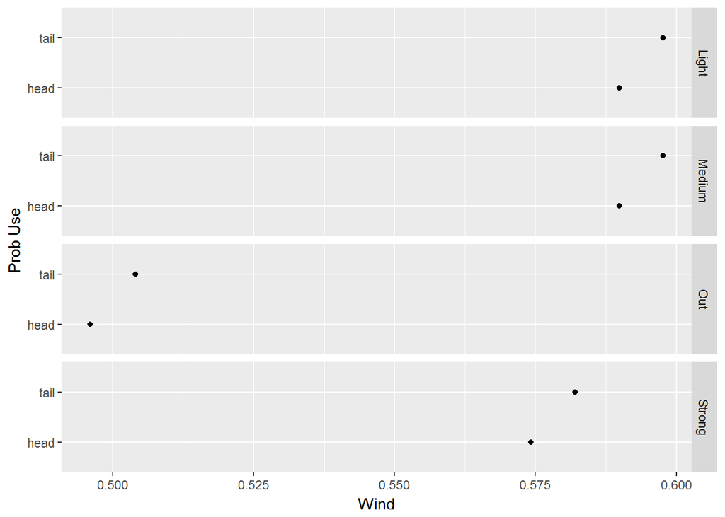

```r
library(ggplot2)
plotdata = data.frame(wind = shuttle$wind,
                      fitted = q2fit$fitted,
                      magn = shuttle$magn)
ggplot(data = plotdata, aes(fitted, wind)) +
    geom_point() +
    facet_grid(magn ~ .) +
    xlab("Wind") + ylab("Prob Use")
```

Odds ratio is the $\beta_1$ coefficient of the fit and is the same as in first question because magn variable does not change the slope of the fit:

```r
exp(q2fit$coef[2])
```

```
##   windBin
## 0.9684981
```

## Question 3

If you fit a logistic regression model to a binary variable, for example use of the autolander, then fit a logistic regression model for one minus the outcome (not using the autolander) what happens to the coefficients?

- The coefficients get inverted (one over their previous value).
- The coefficients reverse their signs.
- The coefficients change in a non-linear fashion.
- The intercept changes sign, but the other coefficients don’t.

The answer is “The coefficients reverse their signs.”

## Question 4

Consider the insect spray data InsectSprays. Fit a Poisson model using spray as a factor level. Report the estimated relative rate comapring spray A (numerator) to spray B (denominator).

- 0.9457
- -0.056
- 0.321
- 0.136

```r
data("InsectSprays")
```

```r
q4fit = glm(data = InsectSprays,
            formula = count ~ I(relevel(spray, ref = "B")),
            family = poisson)
summary(q4fit)
```

```
##
## Call:
## glm(formula = count ~ I(relevel(spray, ref = "B")), family = poisson,
##     data = InsectSprays)
##
## Deviance Residuals:
##     Min       1Q   Median       3Q      Max
## -2.3852  -0.8876  -0.1482   0.6063   2.6922
##
## Coefficients:
##                               Estimate Std. Error z value Pr(>|z|)
## (Intercept)                    2.73003    0.07372  37.032  < 2e-16 ***
## I(relevel(spray, ref = "B"))A -0.05588    0.10574  -0.528    0.597
## I(relevel(spray, ref = "B"))C -1.99606    0.21315  -9.364  < 2e-16 ***
## I(relevel(spray, ref = "B"))D -1.13740    0.14961  -7.602 2.91e-14 ***
## I(relevel(spray, ref = "B"))E -1.47727    0.17101  -8.638  < 2e-16 ***
## I(relevel(spray, ref = "B"))F  0.08338    0.10215   0.816    0.414
## ---
## Signif. codes:  0 '***' 0.001 '**' 0.01 '*' 0.05 '.' 0.1 ' ' 1
##
## (Dispersion parameter for poisson family taken to be 1)
##
##     Null deviance: 409.041  on 71  degrees of freedom
## Residual deviance:  98.329  on 66  degrees of freedom
## AIC: 376.59
##
## Number of Fisher Scoring iterations: 5
```

Answer is:

```r
exp(q4fit$coef[2])
```

```
## I(relevel(spray, ref = "B"))A
##                     0.9456522
```

## Question 5

Consider a Poisson glm with an offset, t. So, for example, a model of the form glm(count ~ x + offset(t), family = poisson) where x is a factor variable comparing a treatment (1) to a control (0) and t is the natural log of a monitoring time. What is impact of the coefficient for x if we fit the model glm(count ~ x + offset(t2), family = poisson) where 2 <- log(10) + t? In other words, what happens to the coefficients if we change the units of the offset variable. (Note, adding log(10) on the log scale is multiplying by 10 on the original scale.)

- The coefficient estimate is divided by 10.
- The coefficient estimate is unchanged
- The coefficient estimate is multiplied by 10.
- The coefficient is subtracted by log(10).

The answer is “The coefficient estimate is unchanged”

## Question 6

Consider the data

```r
x <- -5:5
y <- c(5.12, 3.93, 2.67, 1.87, 0.52, 0.08, 0.93, 2.05, 2.54, 3.87, 4.97)
```

Using a knot point at 0, fit a linear model that looks like a hockey stick with two lines meeting at x=0. Include an intercept term, x and the knot point term. What is the estimated slope of the line after 0?

- -0.183
- 1.013
- -1.024
- 2.037

```r
knots = c(0)
splineTerms = sapply(knots, function(knot) (x > knot) * (x - knot))
xMat = cbind(1, x, splineTerms)
q6fit = lm(y ~ xMat - 1)
summary(q6fit)
```

```
##
## Call:
## lm(formula = y ~ xMat - 1)
##
## Residuals:
##      Min       1Q   Median       3Q      Max
## -0.32158 -0.10979  0.01595  0.14065  0.26258
##
## Coefficients:
##       Estimate Std. Error t value Pr(>|t|)
## xMat  -0.18258    0.13558  -1.347    0.215
## xMatx -1.02416    0.04805 -21.313 2.47e-08 ***
## xMat   2.03723    0.08575  23.759 1.05e-08 ***
## ---
## Signif. codes:  0 '***' 0.001 '**' 0.01 '*' 0.05 '.' 0.1 ' ' 1
##
## Residual standard error: 0.2276 on 8 degrees of freedom
## Multiple R-squared:  0.996,  Adjusted R-squared:  0.9945
## F-statistic:   665 on 3 and 8 DF,  p-value: 6.253e-10
```

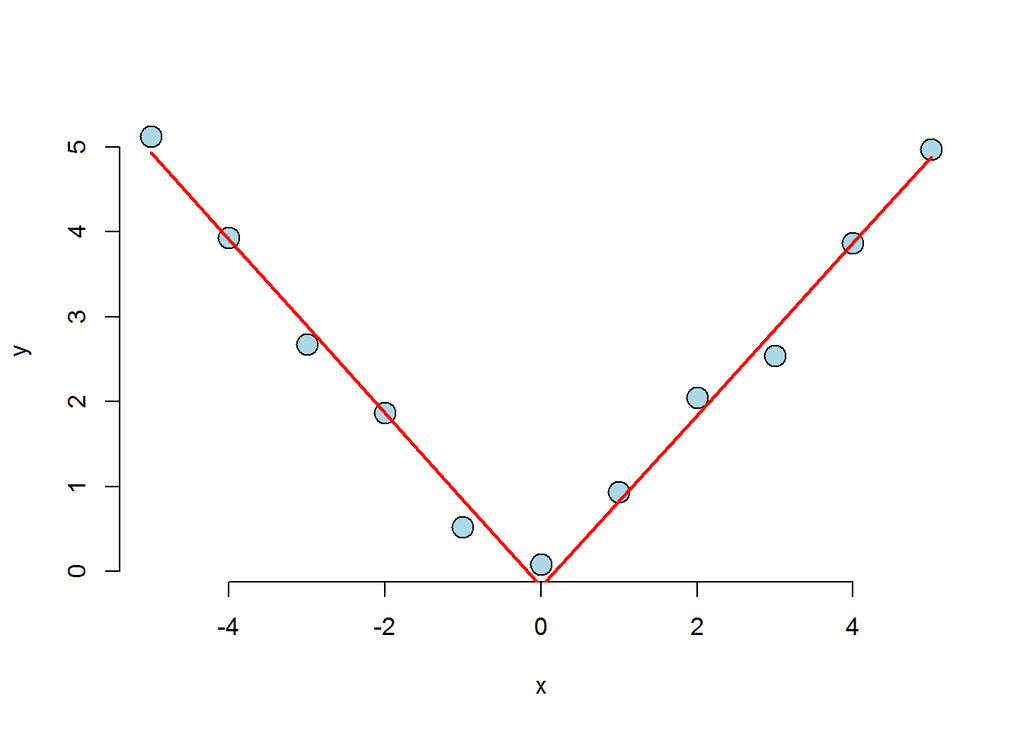

```r
yhat <- predict(q6fit)
plot(x, y, frame = FALSE, pch = 21, bg = "lightblue", cex = 2)
lines(x, yhat, col = "red", lwd = 2)
```

Answer is:

```r
q6fit$coef[2]+q6fit$coef[3]
```

```
##    xMatx
## 1.013067
```